# COVID-19 Pandemic in the Republic of Ethiopia

AS2019532

2022-10-08

# **ABSTRACT**

Covid-19 is spreading rapidly in different parts of the world. If coordinated preventive measures are not taken, the epidemic will have a severe impact. The dataset contains a daily summary of the number of coronavirus cases (confirmed, death and recovered) by Ethiopia. This provides an analysis of the data on Corona confirmed, death and recovered cases

# **1.BACKGROUND**

## **1.1 INTRODUCTION**

The COVID-19 pandemic continues as a significant worldwide health threat. The World Health Organization has declared it a public health emergency of global concern calling for concerted efforts from across all nations to stop the spread of the virus (World Health Organization, 2020). Most African countries face an enormous mission to contain the rapidly spreading pandemic due to poor healthcare and limited resources. However, the Mo Ibrahim Foundation (2020) debates that the continent appears to have comparative advantages to contain the pandemic. The foundation’s claims are based on two viewpoints. First, it is related to the demography as most of its population is in the age of lower than 20 years. The assumption is that younger populations appear to suffer milder symptoms compared to older people. Second, it is associated with a warm climate in that influenza and respiratory viruses mainly transmit during cold rainy seasons. This is related to earlier studies that “high temperature and high relative humidity significantly reduce the transmission of COVID-19” (Wang et al., 2020, p.1). Nevertheless, this was immediately overruled, affirming that the virus could be transmitted to all areas, hot and humid climates (World Heath Organization, 2020b). Based on this, there is no concrete evidence to recognize the foundation’s claims as the COVID-19 is a new pandemic with no explicitly recommended antiviral treatment or vaccine to date. However, these claims represent the rapidly circulating myths and misconceptions in most African countries, including Ethiopia.

### **1.2. Location of Ethiopia**

Ethiopia is the oldest independent country in Africa and one of the world’s oldest - it exists for at least 2,000 years. The country comprises more than 80 ethnic groups and as many languages. Primarily their shared independent existence unites Ethiopia’s many nations.

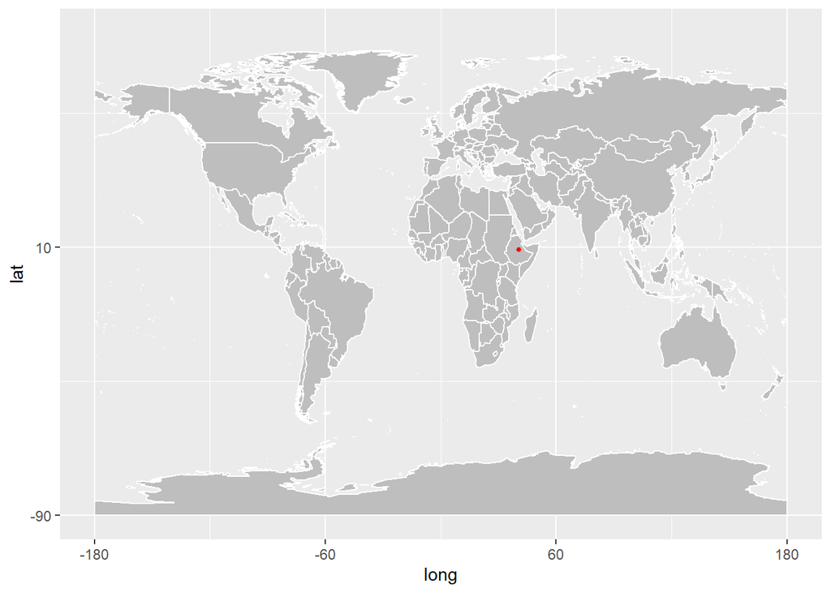

### **1.3 Actions taken by the government**

Immediately after the first confirmed case of COVID-19 in Ethiopia in March 2020, the Government of Ethiopia took several public health measures to prevent increased levels of infection These included closing all schools and restricting large gatherings and movements of people. Hand-washing and social distancing were the main prevention measures that government has communicated to the general public through various media platforms. Using the latest round of the Ethiopian Demographic and Health Survey, COVID-19 relevant indicators related to household access to communication platforms; access to water, sanitation, and hygiene (WASH); and characteristics of the home environment were assessed. The analysis shows that a sizeable proportion of the rural population does not have access to the media platforms used to publicize COVID-19 prevention measures. Moreover, without aggressive interventions, current levels of access to water and soap are suboptimal to adopt the hand-washing recommendations, particularly in rural areas. The low proportion of households with electricity, refrigeration, or internet connection and the relatively high prevalence of partner violence suggest that implementing the stay and work from home measures will be challenging. Public health measures that slow down the transmission of the virus should be continued and efforts to prevent transmission to rural areas should be prioritized. Communication platforms and messaging will need to be adapted to different local realities to make any COVID-19 containment recommendations operational. WASH-related support should be ramped-up, and addressing barriers to staying at home, such as the risk of partner violence, should be considered. The efforts needed to end the current pandemic in Ethiopia, as well as similar pandemics in the future, illuminates the serious challenges related to WASH and to the inequalities between rural and urban areas that need urgent attention.

### **1.5. How Ethiopia compares**

There is no one perfect statistic to compare the outbreaks different countries have experienced during this pandemic. Looking at a variety of metrics gives you a more complete view of the virus’ toll on each country.

# **2 . Exploratory Data Analysis**

There are collect the data from 187 of counties.

```
  [1] "Canada"                           "United Kingdom"
  [3] "China"                            "Netherlands"
  [5] "Australia"                        "New Zealand"
  [7] "Denmark"                          "France"
  [9] "Afghanistan"                      "Albania"
 [11] "Algeria"                          "Andorra"
 [13] "Angola"                           "Antarctica"
 [15] "Antigua and Barbuda"              "Argentina"
 [17] "Armenia"                          "Austria"
 [19] "Azerbaijan"                       "Bahamas"
 [21] "Bahrain"                          "Bangladesh"
 [23] "Barbados"                         "Belarus"
 [25] "Belgium"                          "Belize"
 [27] "Benin"                            "Bhutan"
 [29] "Bolivia"                          "Bosnia and Herzegovina"
```

[output cut: 85 more lines]

## **2.1. COVID-19 Statistics of Ethiopia**

### **2.2. All confirmed Covid-19 Cases in Ethiopia**

```
      date              province           country               lat
 Min.   :2020-01-22   Length:2652        Length:2652        Min.   :9.145
 1st Qu.:2020-08-29   Class :character   Class :character   1st Qu.:9.145
 Median :2021-04-07   Mode  :character   Mode  :character   Median :9.145
 Mean   :2021-04-07                                         Mean   :9.145
 3rd Qu.:2021-11-14                                         3rd Qu.:9.145
 Max.   :2022-06-23                                         Max.   :9.145
      long           type               cases                uid
 Min.   :40.49   Length:2652        Min.   :-264008.0   Min.   :231
 1st Qu.:40.49   Class :character   1st Qu.:      0.0   1st Qu.:231
 Median :40.49   Mode  :character   Median :     15.0   Median :231
 Mean   :40.49                      Mean   :    186.2   Mean   :231
 3rd Qu.:40.49                      3rd Qu.:    394.0   3rd Qu.:231
 Max.   :40.49                      Max.   :   5185.0   Max.   :231
     iso2               iso3               code3     combined_key
 Length:2652        Length:2652        Min.   :231   Length:2652
 Class :character   Class :character   1st Qu.:231   Class :character
 Mode  :character   Mode  :character   Median :231   Mode  :character
                                       Mean   :231
                                       3rd Qu.:231
                                       Max.   :231
   population       continent_name     continent_code
 Min.   :1.15e+08   Length:2652        Length:2652
 1st Qu.:1.15e+08   Class :character   Class :character
 Median :1.15e+08   Mode  :character   Mode  :character
 Mean   :1.15e+08
 3rd Qu.:1.15e+08
 Max.   :1.15e+08
```

```
        date province  country   lat    long      type cases uid iso2 iso3
1 2020-01-22     <NA> Ethiopia 9.145 40.4897 confirmed     0 231   ET  ETH
2 2020-01-23     <NA> Ethiopia 9.145 40.4897 confirmed     0 231   ET  ETH
3 2020-01-24     <NA> Ethiopia 9.145 40.4897 confirmed     0 231   ET  ETH
4 2020-01-25     <NA> Ethiopia 9.145 40.4897 confirmed     0 231   ET  ETH
5 2020-01-26     <NA> Ethiopia 9.145 40.4897 confirmed     0 231   ET  ETH
6 2020-01-27     <NA> Ethiopia 9.145 40.4897 confirmed     0 231   ET  ETH
  code3 combined_key population continent_name continent_code
1   231     Ethiopia  114963583         Africa             AF
2   231     Ethiopia  114963583         Africa             AF
3   231     Ethiopia  114963583         Africa             AF
4   231     Ethiopia  114963583         Africa             AF
5   231     Ethiopia  114963583         Africa             AF
6   231     Ethiopia  114963583         Africa             AF
```

```
[1] 486373
```

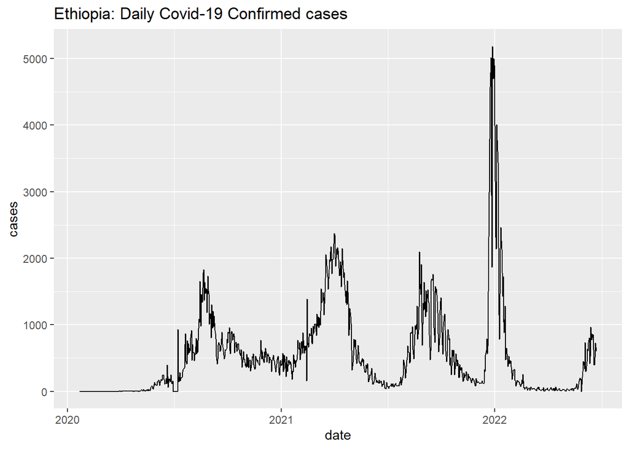

**Figure 1**

### **2.3. All Deaths of Covid-19 Cases in Ethiopia**

```
        date province  country   lat    long  type cases uid iso2 iso3 code3
1 2020-01-22     <NA> Ethiopia 9.145 40.4897 death     0 231   ET  ETH   231
2 2020-01-23     <NA> Ethiopia 9.145 40.4897 death     0 231   ET  ETH   231
3 2020-01-24     <NA> Ethiopia 9.145 40.4897 death     0 231   ET  ETH   231
4 2020-01-25     <NA> Ethiopia 9.145 40.4897 death     0 231   ET  ETH   231
5 2020-01-26     <NA> Ethiopia 9.145 40.4897 death     0 231   ET  ETH   231
6 2020-01-27     <NA> Ethiopia 9.145 40.4897 death     0 231   ET  ETH   231
  combined_key population continent_name continent_code
1     Ethiopia  114963583         Africa             AF
2     Ethiopia  114963583         Africa             AF
3     Ethiopia  114963583         Africa             AF
4     Ethiopia  114963583         Africa             AF
5     Ethiopia  114963583         Africa             AF
6     Ethiopia  114963583         Africa             AF
```

```
[1] 7526
```

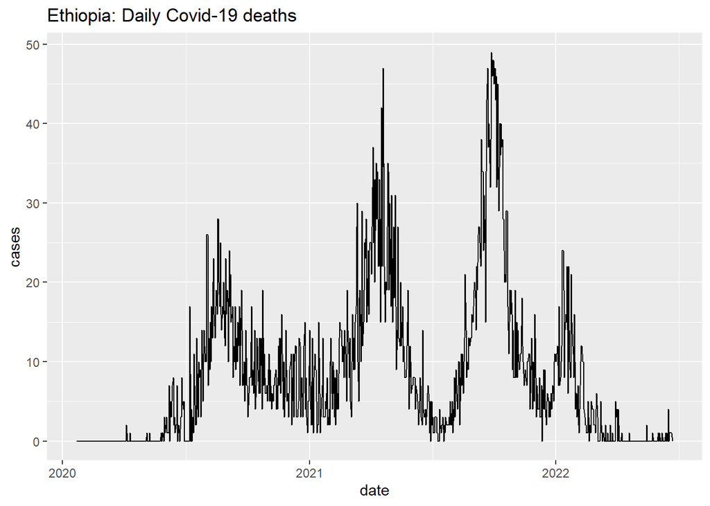

**Figure 2**

According to the chart we can see the highest number of deaths in 2021 and the number of deaths decreases in the middle of the year and again shows an increase in the number of deaths at the end of the year.

### **2.4. All Covid-19 Recovery Cases in Ethiopia**

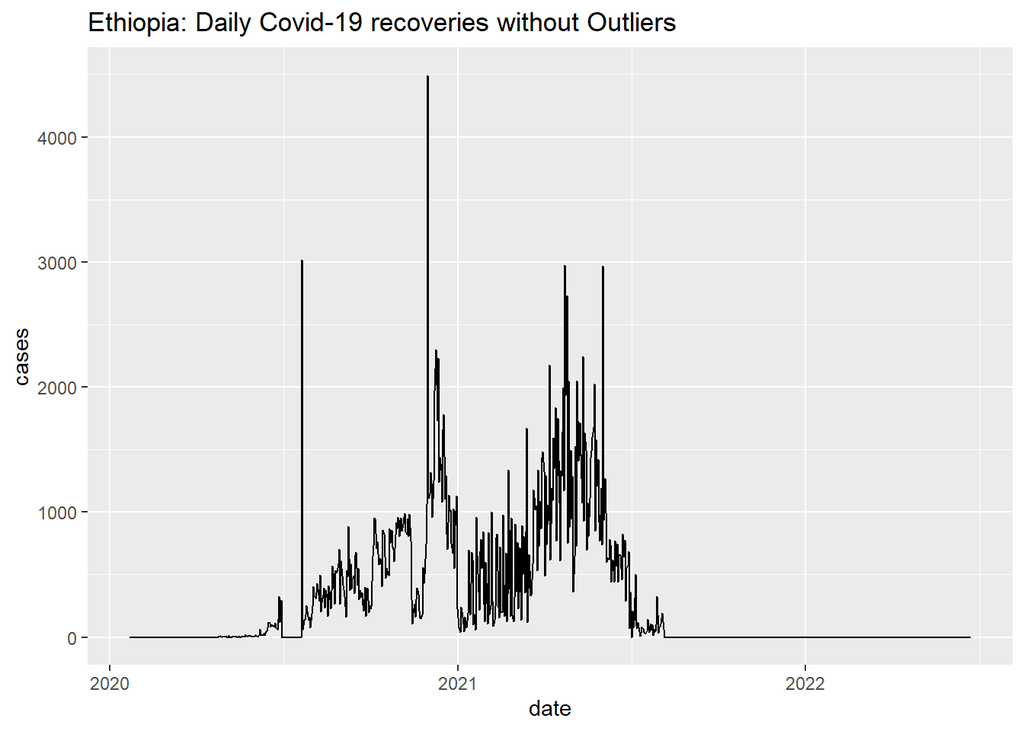

```
[1] 264014
```

**Figure 3**

The total recovered cases: Ethiopia in this data set is only 264014.his is approximately 54.28% from the confirmed cases in Ethiopia.

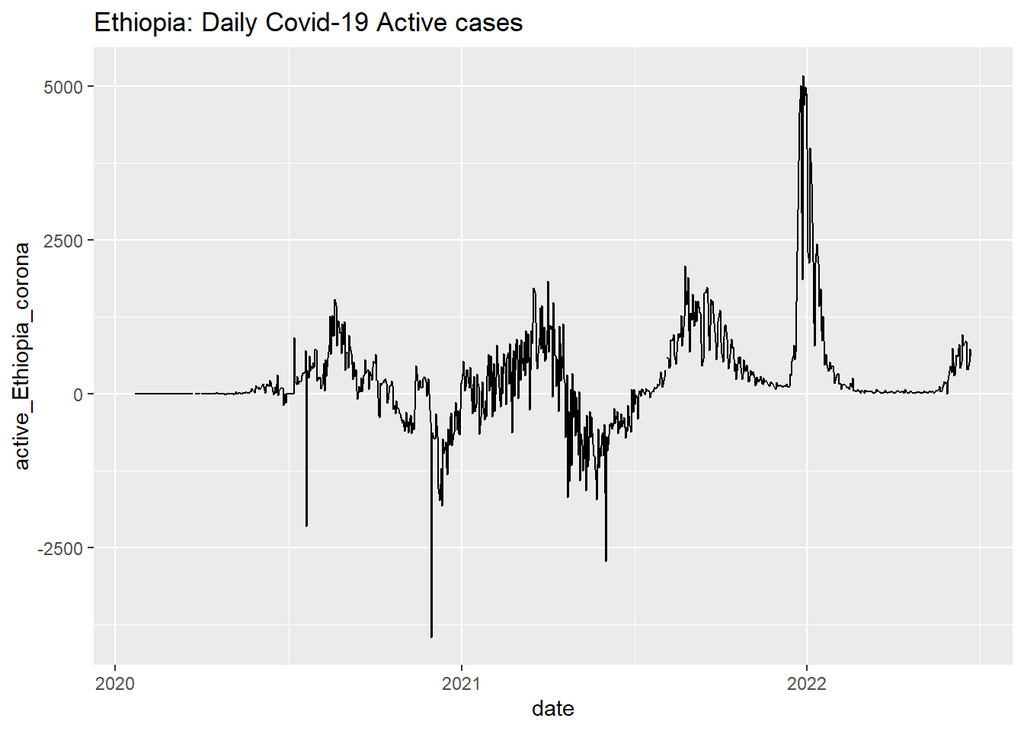

**Figure 5**

### **2.6. Summery of total number of Covid-19 cases in Ethiopia in the year 20-22**

| Confirmed | Deaths | Recovered | Active |
| --- | --- | --- | --- |
| 486373 | 7526 | 264014 | 214833 |

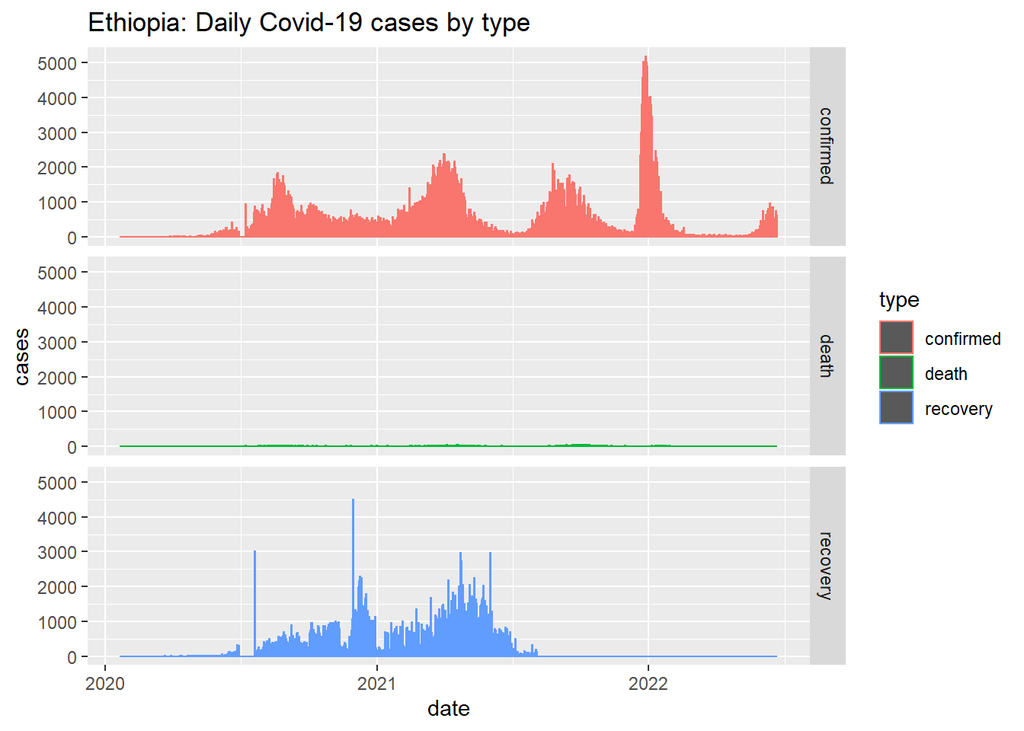

**Figure 6**

[figure not shown]

**Figure 7**